# Practical Machine Learning - Selection of the Predictive Model

Tanaya Narayan Prabhu

29/11/2020

## Overview

[output not shown]

## Summary

[output not shown]

```
Data

The training data for this project are available here:

https://d396qusza40orc.cloudfront.net/predmachlearn/pml-training.csv

The test data are available here:

https://d396qusza40orc.cloudfront.net/predmachlearn/pml-testing.csv
```

# Data Processing

```r
# Libraries
library(knitr)
library(dplyr)
```

```r
library(rpart)
library(rpart.plot)
library(rattle)
library(randomForest)
library(corrplot)
library(caret)
library(RColorBrewer)
library(gbm)
# Set seed to create reproducibility
set.seed(12345)
```

# Loading the Data

```r
TrainData <- read.csv(url("https://d396qusza40orc.cloudfront.net/predmachlearn/pml-training.csv"),header=TRUE)
print(dim(TrainData))
```

```
## [1] 19622   160
```

```r
ValidData <- read.csv(url("https://d396qusza40orc.cloudfront.net/predmachlearn/pml-testing.csv"),header=TRUE)
print(dim(ValidData))
```

```
## [1]  20 160
```

```r
print(str(TrainData))
```

```
## 'data.frame':    19622 obs. of  160 variables:
##  $ X                       : int  1 2 3 4 5 6 7 8 9 10 ...
##  $ user_name               : chr  "carlitos" "carlitos" "carlitos" "carlitos" ...
##  $ raw_timestamp_part_1    : int  1323084231 1323084231 1323084231 1323084232 1323084232 1323084232 1323084232 1323084232 1323084232 1323084232 ...
##  $ raw_timestamp_part_2    : int  788290 808298 820366 120339 196328 304277 368296 440390 484323 484434 ...
##  $ cvtd_timestamp          : chr  "05/12/2011 11:23" "05/12/2011 11:23" "05/12/2011 11:23" "05/12/2011 11:23" ...
##  $ new_window              : chr  "no" "no" "no" "no" ...
##  $ num_window              : int  11 11 11 12 12 12 12 12 12 12 ...
##  $ roll_belt               : num  1.41 1.41 1.42 1.48 1.48 1.45 1.42 1.42 1.43 1.45 ...
##  $ pitch_belt              : num  8.07 8.07 8.07 8.05 8.07 8.06 8.09 8.13 8.16 8.17 ...
##  $ yaw_belt                : num  -94.4 -94.4 -94.4 -94.4 -94.4 -94.4 -94.4 -94.4 -94.4 -94.4 ...
##  $ total_accel_belt        : int  3 3 3 3 3 3 3 3 3 3 ...
##  $ kurtosis_roll_belt      : chr  "" "" "" "" ...
##  $ kurtosis_picth_belt     : chr  "" "" "" "" ...
##  $ kurtosis_yaw_belt       : chr  "" "" "" "" ...
```

[output cut: 87 more lines]

# Data Cleaning

```r
# Removing NA's, empty values, and unnecesary variables in the Trainning dataset.
EmptyCols <- which(colSums(is.na(TrainData) |TrainData=="")>0.9*dim(TrainData)[1])
TrainDataClean <- TrainData[,-EmptyCols]
TrainDataClean <- TrainDataClean[,-c(1:7)]
print(dim(TrainDataClean))
```

```
## [1] 19622    53
```

```r
# Removing NA's, empty values in the Test dataset.
EmptyCols <- which(colSums(is.na(ValidData) |ValidData=="")>0.9*dim(ValidData)[1])
ValidDataClean <- ValidData[,-EmptyCols]
ValidDataClean <- ValidDataClean[,-1]
print(dim(ValidDataClean))
```

```
## [1] 20 59
```

# Low variation data exclusion

```r
# Low variation data exclusion from the TrainData Dataset
NZV <- nearZeroVar(TrainDataClean)
print(NZV)
```

```
## integer(0)
```

Acording to this, all the current variables report some variation. No more variables need to be removed from the training dataset.

# Data Partitioning for prediction

```r
set.seed(12345)
inTrain <- createDataPartition(TrainDataClean$classe, p = 0.7, list = FALSE)
TrainData <- TrainDataClean[inTrain, ]
TestData <- TrainDataClean[-inTrain, ]
print(dim(TrainData))
```

```
## [1] 13737    53
```

After cleaning, the new training data set has only 53 columns.

## Exploratoy Data Analysis

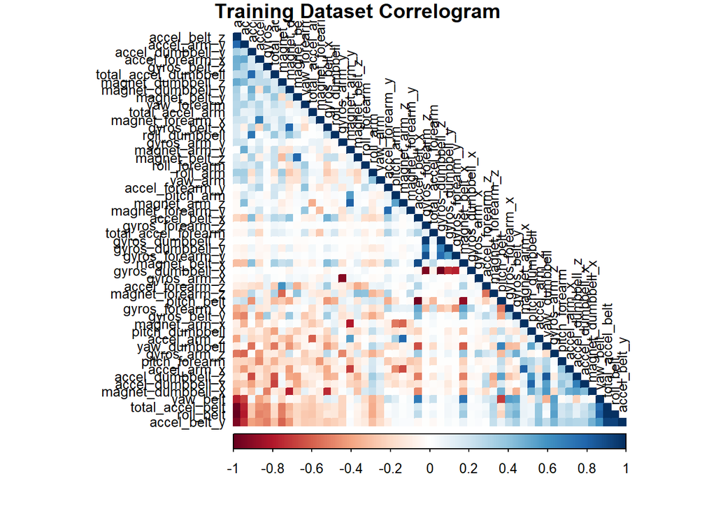

```r
corMatrix <- cor(TrainData[, -53])
corrplot(corMatrix, order = "FPC", method = "color", type = "lower",
         tl.cex = 0.8, tl.col = rgb(0, 0, 0),mar = c(1, 1, 1, 1), title = "Training Dataset Correlogram")
```

All the correlations have a darker tone of blue if it’s closer to 1, and a darker tone of red when it’s closer to -1, which means a stronger relationship in both cases.

```r
# Count the number of variables that are highly correlated with another one
M <- abs(cor(TrainData[,-53])); diag(M) <- 0
M <- which(M > 0.8, arr.ind = T)
M <- dim(M)[1]
print(M)
```

```
## [1] 38
```

## Selection of the Predictive Model

```
To predict the outcome, we will use two different methods to model the regression using the TrainData dataset:
- Decision Trees
- Random Forest
Then, they will be applied to the TestData dataset to compare accuracies. The best model will be our Final model.
```

# Cross Validation

Cross-validation is done for each model with K = 3.

```r
fitControl <- trainControl(method='cv', number = 3)
```

# Decision Trees Model

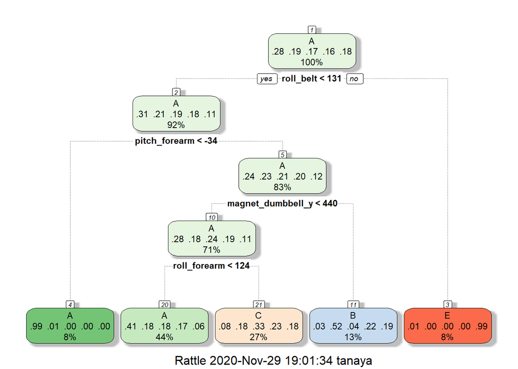

```r
# Decision Trees Model
DT_Model <- train(classe~., data=TrainData, method="rpart", trControl=fitControl)
#  Plot
fancyRpartPlot(DT_Model$finalModel)
```

Now we validate the model to see it’s performance by looking at the accuracy variable.

```r
# Testing the model
DT_Predict <- predict(DT_Model, newdata=TestData)
DT_cm <- confusionMatrix(DT_Predict, as.factor(TestData$classe))
# Display confusion matrix and model accuracy
print(DT_cm)
```

```
## Confusion Matrix and Statistics
##
##           Reference
## Prediction    A    B    C    D    E
##          A 1525  484  499  423  153
##          B   29  385   37  187  159
##          C  116  270  490  354  289
##          D    0    0    0    0    0
##          E    4    0    0    0  481
##
## Overall Statistics
##
##                Accuracy : 0.4895
##                  95% CI : (0.4767, 0.5024)
##     No Information Rate : 0.2845
##     P-Value [Acc > NIR] : < 2.2e-16
##
##                   Kappa : 0.3324
##
##  Mcnemar's Test P-Value : NA
##
## Statistics by Class:
##
##                      Class: A Class: B Class: C Class: D Class: E
## Sensitivity            0.9110  0.33802  0.47758   0.0000  0.44455
## Specificity            0.6298  0.91319  0.78823   1.0000  0.99917
## Pos Pred Value         0.4945  0.48306  0.32258      NaN  0.99175
## Neg Pred Value         0.9468  0.85181  0.87723   0.8362  0.88870
## Prevalence             0.2845  0.19354  0.17434   0.1638  0.18386
## Detection Rate         0.2591  0.06542  0.08326   0.0000  0.08173
## Detection Prevalence   0.5240  0.13543  0.25811   0.0000  0.08241
## Balanced Accuracy      0.7704  0.62560  0.63291   0.5000  0.72186
```

```r
# Model Accuracy
print(DT_cm$overall[1])
```

```
##  Accuracy
## 0.4895497
```

Using cross-validation, the accuracy of this first model is about 0.489.Therefore the out-of-sample-error is 0.5, which is high.

## Random Forest Model

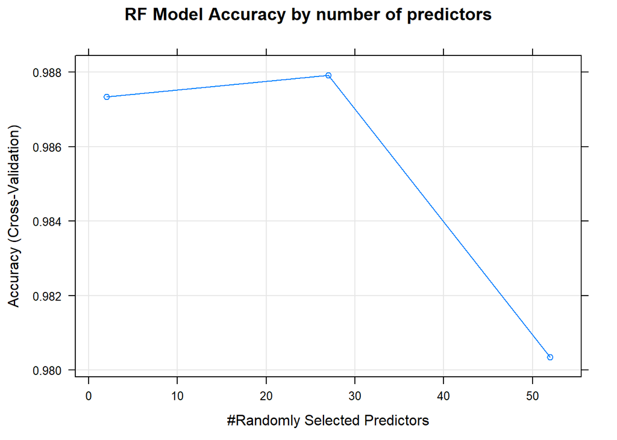

```r
# Random Forest Model
RF_Model <- train(classe~., data=TrainData, method="rf", trControl=fitControl, verbose=FALSE)
# Plot
plot(RF_Model,main="RF Model Accuracy by number of predictors")
```

Now we validate the model to see it’s performance by looking at the accuracy variable.

```r
# Testing the model
RF_Predict <- predict(RF_Model, newdata=TestData)
RF_cm <- confusionMatrix(RF_Predict, as.factor(TestData$classe))
# Display confusion matrix and model accuracy
print(RF_cm)
```

```
## Confusion Matrix and Statistics
##
##           Reference
## Prediction    A    B    C    D    E
##          A 1673    6    0    0    0
##          B    1 1130    5    0    0
##          C    0    3 1018    8    2
##          D    0    0    3  955    1
##          E    0    0    0    1 1079
##
## Overall Statistics
##
##                Accuracy : 0.9949
##                  95% CI : (0.9927, 0.9966)
##     No Information Rate : 0.2845
##     P-Value [Acc > NIR] : < 2.2e-16
##
##                   Kappa : 0.9936
##
##  Mcnemar's Test P-Value : NA
##
## Statistics by Class:
##
##                      Class: A Class: B Class: C Class: D Class: E
## Sensitivity            0.9994   0.9921   0.9922   0.9907   0.9972
## Specificity            0.9986   0.9987   0.9973   0.9992   0.9998
## Pos Pred Value         0.9964   0.9947   0.9874   0.9958   0.9991
## Neg Pred Value         0.9998   0.9981   0.9984   0.9982   0.9994
## Prevalence             0.2845   0.1935   0.1743   0.1638   0.1839
## Detection Rate         0.2843   0.1920   0.1730   0.1623   0.1833
## Detection Prevalence   0.2853   0.1930   0.1752   0.1630   0.1835
## Balanced Accuracy      0.9990   0.9954   0.9948   0.9949   0.9985
```

```r
# Model Accuracy
print(RF_cm$overall[1])
```

```
##  Accuracy
## 0.9949023
```

Using cross-validation, the model accuracy is 0.994. Therefore the out-of-sample-error is 0.006.

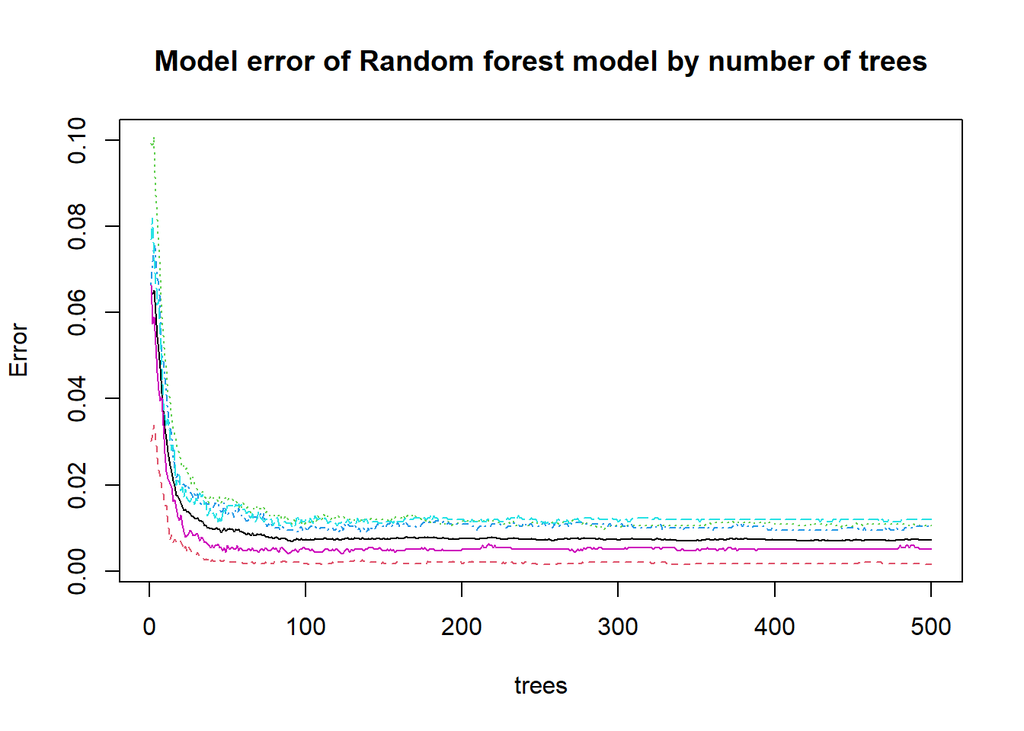

```r
plot(RF_Model$finalModel,main="Model error of Random forest model by number of trees")
```

## Prediction of the values of classe for the validation data

By looking all the accuracy rate values of the models, we select ‘Random Forest’ model.

```r
# Model Validation
Prediction_Test <- predict(RF_Model,newdata=ValidDataClean)
print(Prediction_Test)
```

```
##  [1] B A B A A E D B A A B C B A E E A B B B
## Levels: A B C D E
```

## Conclusion

```
The confusion matrices shows that the Random Forest algorithm performs better than decision trees. The accuracy for the Random Forest model is 0.994 compared to 0.489 for Decision Tree model. Hence our selected predictive model is Random Forest model.
```